# Lecture 5 - Hypothesis testing

Author: Matthew J. Cossley

Last update: 25 April, 2022

## Learning objectives

- Define and understand null hypothesis significance testing.
- Define and understand **p-value**.
- Define and understand **more extreme outcomes** in the context of hypothesis testing.
- Define and understand **critical value**.
- Define and understand **rejection region**.
- Be able to perform hypothesis binomial tests and t-tests manually (i.e., run through the 5 steps).
- Understand when and how to use `binom.test()`.
- Understand when and how to use `t.test()`.

## Null Hypothesis Significance Testing

We will unpack each of these 5 steps in the examples that follow. They are listed here for reference.

1. Specify the null and alternative hypotheses ($H_0$ and $H_1$) in terms of a population parameter $\theta$.
2. Specify the type I error rate – denoted by the symbol $\alpha$ – you are willing to tolerate.
3. Specify the sample statistic $\widehat{\theta}$ that you will use to estimate the population parameter $\theta$ in step 1 and state how it is distributed under the assumption that $H_0$ is true.
4. Obtain a random sample and use it to compute the sample statistic from step 3. Call this value $\widehat{\theta}_{\text{obs}}$.
5. If $\widehat{\theta}_{\text{obs}}$ or a **more extreme outcome is very unlikely to occur under the assumption that $H_0$ is true, then reject $H_0$. Otherwise, do not reject $H_0$.

## Binomial Test

Consider an experiment in which researchers are trying to determine if a particular rat has learned to press one of two levers whenever they are placed inside of an experimental apparatus. Intuitively, answering this questions would be as simple as just watching the rat and taking note of whether it pressed the correct lever or not. The trouble is that rat behaviour is somewhat random: it sometimes pressed the correct lever and sometimes presses the incorrect lever.

Suppose that the experiment contained $n=100$ trials and the number of trials in which the rat pressed the lever was $n_{\text{pressed}}=61$. Did the rat learn or not? We turn to **Null Hypothesis Significance Testing (NHST)** to answer this question.

#### 1. Specify the null and alternative hypotheses ($H_0$ and $H_1$) in terms of a distribution and population parameter.

First, decide on a statistical model for the measurements you are trying to reason about. That is, think of your data as being samples from a random variable. What distribution does that random variable have? We have a rat that either presses the correct lever or doesn’t. This is a dichotomous outcome, so we know that Binomial distribution is a good model. Recall that the binomial has two parameters, (1) the number of trials $n$ and (2) the probability of success $p$. The number of trials is fixed for us by our experiment ($n=100$), and $p$ is the very thing we are trying to reason about. If $p=0.5$ then the rat is just guessing at the levers. This corresponds to a null result, and therefore to the null hypothesis $H_0$. If $p>0.5$ then the rat is doing better than guessing and we would say that it has learned. Therefore, this corresponds to the alternative hypothesis $H_1$. Let $X$ be the binomial random variable that generates the results in the above experiment. Then,

$$X \sim binomial(n=100, p) \\
H_0: p = 0.5 \\
H_1: p > 0.5$$

#### 2. Specify the type I error rate – denoted by the symbol $\alpha$ – you are willing to tolerate.

It is traditional in psychology and neuroscience to tolerate a $5\%$ type I error rate in our inference procedure. This means that 5 out of every 100 times we think the rat has learned, we will have made an incorrect conclusion.

$$\alpha=0.05$$

#### 3. Specify the sample statistic that you will use to estimate the population parameter in step 1 and state how it is distributed under the assumption that $H_0$ is true.

We are trying to make an inference about the population parameter $p$. An intuitive estimate of this parameter is the proportion of successful trials relative to all trials performed. Let $x$ be the be the count of successful trials. Then,

$$\widehat{p}=\frac{x}{n}$$

We know that $X$ is Binomial, but what about $\widehat{p}$? With some careful thinking, we can see that $\widehat{p}$ is also Binomial. The possible outcomes of $X$ just need to be normalised by the total number of observations $n$. The probabilities associated with each outcome are the same as those that corresponded to the $X$ distribution. Another approach (not taken here) is to rephrase the hypotheses to be in terms of counts instead of proportions (e.g., $H_0: np = 50; H_0: np > 50$). The **sampling distribution** of $\widehat{p}$ under the null is as follows:

$$\widehat{p} = \frac{X}{n} \sim binomial(n=100, p=0.5), x \rightarrow \frac{x}{n}$$

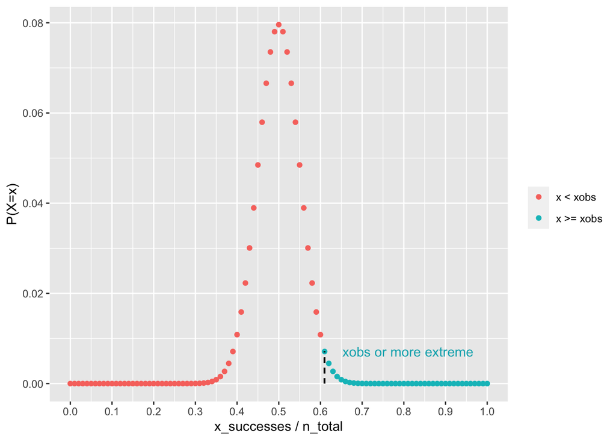

#### 4. Obtain a random sample and use it to compute the sample statistic from step 3. Call this value $\widehat{\theta}_{\text{obs}}$

This was given to us in the formulation of the example. The key is to understand that in this example, $\widehat{\theta}_{\text{obs}} = \widehat{p}_{\text{obs}}$.

$$\widehat{p}_{\text{obs}}=\frac{61}{100}$$

#### 5. If $\widehat{\theta}_{\text{obs}}$ is very unlikely to occur under the assumption that $H_0$ is true, then reject $H_0$. Otherwise, do not reject $H_0$.

$$\text{if } P(\widehat{\theta} \geq \widehat{\theta}_{\text{obs}} | H_0) \leq \alpha \rightarrow \text{Reject } H_0\\
\text{otherwise fail to reject } H_0$$

**Notice that our logic only allows to reject or fail to reject the null hypothesis.** We can’t make any inference about the alternative hypothesis (e.g., we can’t accept the alternative). We are only assessing the evidence for the null. The purpose of including an alternative hypothesis is to give meaning to what sorts of outcomes correspond to more extreme than what we observed.

To proceed, note again that in this example $\widehat{\theta}_{\text{obs}} = \widehat{p}_{\text{obs}}$. We therefore need to compute

$$P(\widehat{p} \geq \widehat{p}_{\text{obs}} | H_0)$$

When actually computing the p-value, we will turn to `pbinom()`. From the plot above, and from reasoning about the alternative hypothesis, we see that we need `lower.tail=FALSE`.

```r
n <- 100
xobs <- 61 # observed count
phatobs <- xobs / n # observed proporion

## `xobs-1` because `lower.tail=FALSE` give P(X > x)
## but we want P(X >= x)
pval <- pbinom(xobs-1, n, p, lower.tail=FALSE)
pval
```

```
## [1] 0.0176001
```

```r
## Notice that in the above we used `xobs` and not `phatobs`.
## This is becuase `pbinom()` needs counts, not proportions
## to functino properly. The probability it returns for `xobs`
## will perfectly correspond to the probabiliy of `phatobs`
## because of the notes discussed above in step 3
```

The decision rule above can also be expressed in terms of a **critical value**. The critical value $\widehat{\theta}_{\text{crit}}$ in NHST is the outcome such that $P(\widehat{\theta} \geq \widehat{\theta}_{\text{crit}} | H_0) \leq \alpha$.

As such, any observed outcome equal to the critical value or more extreme than the critical value will lead to the rejection of the null. For this reason, values more extreme than the critical value are said reside in the **rejection region**.

To obtain critical values, we need to get an outcome that corresponds to a specific probability. This is given to us by the `qbinom()` function, again with `lower.tail=FALSE`.

```r
n <- 100
p <- 0.5
xcrit <- qbinom(0.05, n, p, lower.tail=FALSE)

## Have to divide by n because we are working with
## proportions not counts
phatcrit <- xcrit / n

xcrit
```

```
## [1] 58
```

```r
phatcrit
```

```
## [1] 0.58
```

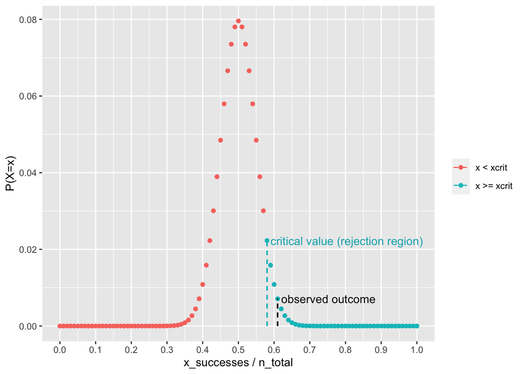

The five steps outlined above are the core of null-hypothesis significance testing, and working through each step in the longhand format that we just did is important to be able to do. This is because these five steps are completely general and will perfectly apply to any situation you might find yourself in. That said, in many situations, `R` has built-in functions to handle all five steps in one line of code. When making inferences from a binomial distribution, you can use the `binom.test()` function.

```r
xobs <- 61       ## number of observed successes
n <- 100         ## n parameter of H0
p <- 0.5         ## p parameter of H0
alpha <- 0.05    ## error rate tolerance
alt <- 'greater' ## test direction

## Use built in `binom.test()`
binom.test(xobs,
           n,
           p,
           alternative = alt,
           conf.level = 1 - alpha
           )
```

```
##
##  Exact binomial test
##
## data:  xobs and n
## number of successes = 61, number of trials = 100, p-value = 0.0176
## alternative hypothesis: true probability of success is greater than 0.5
## 95 percent confidence interval:
##  0.5230939 1.0000000
## sample estimates:
## probability of success
##                   0.61
```

## Normal test

Consider an experiment in which a rat is placed into a maze and given the chance to search for a bit of cheese hidden somewhere in the maze. After much training, the researchers are interested in assessing whether or not the animal has learned where the cheese is hidden. The researchers also know that rats without any training whatsoever find the cheese on average in 90 seconds with a standard deviation of 20 seconds. They perform 15 trials and measure the time to cheese on each trial. The data are as follows:

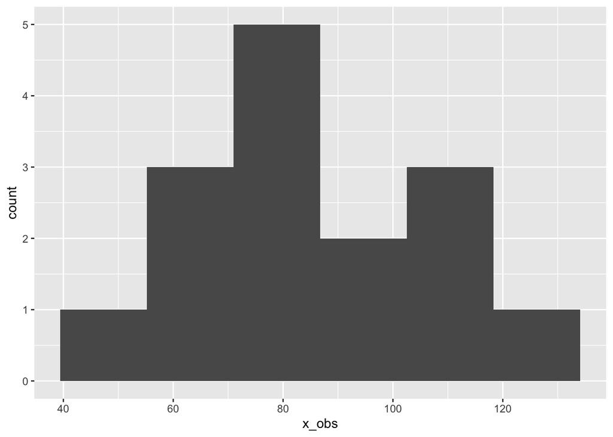

#### 1. Specify the null and alternative hypotheses ($H_0$ and $H_1$) in terms of a distribution and population parameter.

If the rat has learned something about where to find the cheese, then we expect it’s time to be less than that of naive rats, which we are told is 90 seconds. This leads to the following hypotheses.

$$H_0: \mu = 90 \\
H_1: \mu < 90$$

#### 2. Specify the type I error rate – denoted by the symbol $\alpha$ – you are willing to tolerate.

$$\alpha = 0.05$$

#### 3. Specify the sample statistic that you will use to estimate the population parameter in step 1 and state how it is distributed under the assumption that $H_0$ is true.

$$\widehat{\mu} = \bar{x} \\
\bar{x} \sim \mathcal{N}(\mu_{\bar{x}}, \sigma_{\bar{x}})$$

Since we are the sample mean $\bar{x}$ to estimate $\mu$, the sampling distribution of our test statistic is the distribution of sample means. This is great news because we know from previous lectures how the mean and variance of the distribution of sample means $\bar{x}$ relates to the mean and variance of our origin distribution $x$. In particular, we know:

$$\mu_{\bar{x}} = \mu_{x} \\
\sigma_{\bar{x}} = \frac{\sigma_{x}}{\sqrt{n}}$$

We can now inspect the sampling distribution under the assumption that $H_0$ is true, and inspect how likely the observed $\bar{x}$ is to be sampled from this distribution.

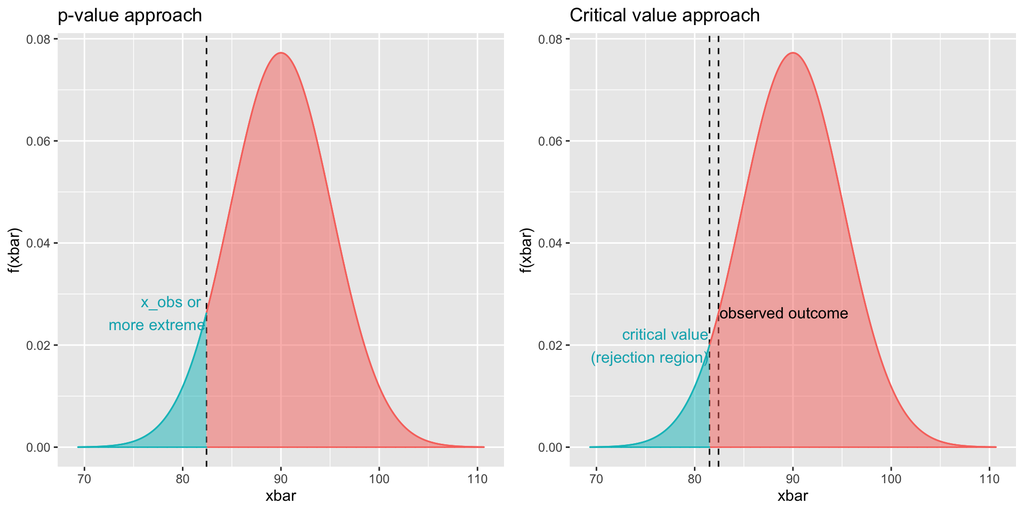

#### 4. Obtain a random sample and use it to compute the sample statistic from step 3. Call this value $\widehat{\theta}_{\text{obs}}$

In this example, $\widehat{\theta}_{\text{obs}}$ corresponds to the observed sample mean. The data, sampled from the random variable $X$ is given by the following times:

```r
x_obs
```

```
##  [1] 105.25909  73.47533 106.59599 105.44859  88.29283  49.20100  61.42866
##  [8]  74.10559  79.88466 128.09307  95.27187  64.01982  57.04686  74.21077
## [15]  74.01570
```

Thus, the observed sample mean $\bar{x}_{\text{obs}}$, sampled from the random variable $\bar{X}$, is obtained as follows:

```r
x_bar_obs <- mean(x_obs)
```

- Therefore, $\bar{x}_{\text{obs}}=$ 82.4233202

#### 5. If $\widehat{\theta}_{\text{obs}}$ is very unlikely to occur under the assumption that $H_0$ is true, then reject $H_0$. Otherwise, do not reject $H_0$.

When computing the p-value, we will turn to `pnorm()`. From the plot above, and from reasoning about the alternative hypothesis, we see that we need `lower.tail=TRUE`.

```r
mu_x <- 90
sig_x <- 20

mu_x_bar <- mu_x
sig_x_bar <- sig_x / sqrt(n)

## p-value
pval <- pnorm(x_bar_obs, mu_x_bar, sig_x_bar, lower.tail=TRUE)
pval
```

```
## [1] 0.07115842
```

```r
## critical value
x_bar_crit <- qnorm(0.05, mu_x_bar, sig_x_bar, lower.tail=TRUE)
x_bar_crit
```

```
## [1] 81.50601
```

It is easy to decide whether or not to reject $H_0$ based on the p-value or the critical region, but it sure would be nice if R gave us a one liner like `binom.test()`. Unfortunately, in the case of a normal sampling distribution, no such R function exists. The reason for this is that to have a normal $\bar{x}$ sampling distribution, you have to know both the mean and the variance of the $H_0$ distribution. The mean is specified by $H_0$ so is no issue, but we rarely are in a situation to know the population variance of X, and we therefore have to estimate it. This leads us to the famous t-test.

## The z-test

- Why is the $Z$ distribution so important?
- To be candid, for the privileged `R` users of the world, it really isn’t that essential to our day to day statistical adventures.
- This is because, if we want to know what $P(X < x)$ for $X \sim N(\mu_X, \sigma_x)$ then we just type `pnorm(x, mu_x, sigma_x, lower.tail=TRUE)` and let R do all the hard work.
- But what is R doing under the hood?
- Recall that $P(X < x)$ for $X \sim N(\mu_X, \sigma_x)$ corresponds to the area under the probability density function in the interval $[-\infty, x]$.
- Further recall that the equation that describes the PDF of a normal distribution is given by:

$$f(x) = \frac{1}{\sigma_X \sqrt(2 \pi)} e^{ -\frac{1}{2} (\frac{x - \mu_X}{\sigma_X})^2 }$$

- This means that $P(X < x)$ is given by:

$$P(X < a) = \int_{\infty}^{a}
\frac{1}{\sigma_X \sqrt(2 \pi)} e^{ -\frac{1}{2} (\frac{x - \mu_X}{\sigma_X})^2 }$$

- It turns out that without awesome computer programs like R, evaluating this integral is challenging.
- The old school solution to this challenge was to evaluate this integral for the standard normal ($Z$) and put that solution in the back of standard statistics text books in the form of big giant tables.
- The $Z$ distribution has other uses in statistics and machine learning, but most of them are beyond the scope of this unit.
- We will see that the overarching idea of the z-transform – i.e., standardising data to mean zero and variance one – comes up when we get to the t-test (later this lecture!).

```r
# Using Normal distribution
x_bar_obs <- mean(x_obs)
sig_x_bar <- sig_x / sqrt(n)
px <- pnorm(x_bar_obs, mu_x_bar, sig_x_bar, lower.tail=TRUE)

## Using Z distribution
z_obs <- (x_bar_obs - 90) / sig_x_bar
pz <- pnorm(z_obs, 0, 1, lower.tail=TRUE)

## Compare p-values from different methods
px
```

```
## [1] 0.07115842
```

```r
pz
```

```
## [1] 0.07115842
```

- How are the p-values the same?
- The plot below is the X distribution on the left and the Z distribution on the right. - Notice that the Z is just a scaled version of X, and the that scaling also applied to the observed value.
- This means that all probabilities (area under the curve) are the same.

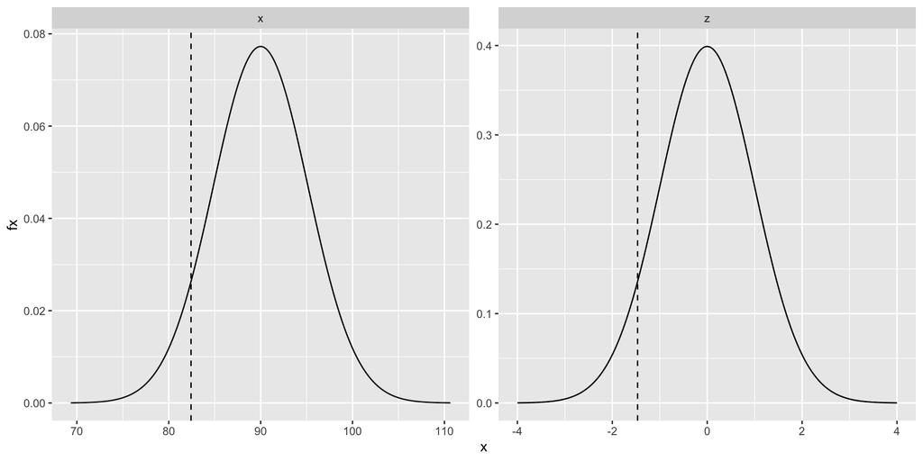

## t-test

So far, everything that we have done we have been lucky enough to know both the mean and the variance of the sampling distribution in our hypothesis tests. The mean is specified in $H_0$ and $H_1$ and the variance has either fallen out luckily (e.g., as with the Binomial test), or I have just given you a number and told you pretend that we just know it to be true (e.g., previous cheese maze example). Of course, in most real world scenarios, we will not know the variance of the sampling distribution, and this means that the approaches we have developed so far aren’t quite appropriate. Here is what we do instead:

Let $X_1, X_2, \ldots, X_n$ be independent and identically distributed as

$$X_i \sim N(\mu_X, \sigma_X)$$

and define two random variables $\bar{X}$ and $S^2$ as

$$\bar{X} = \frac{1}{n} \sum_{i=1}^{n} X_i$$

$$S^2 = \frac{1}{n-1} \sum_{i=1}^{n} (X_i - \bar{X})^2$$

then the random variable

$$\frac{\bar{X} - \mu_X}{\frac{\sigma_X}{\sqrt{n}}} \sim N(0, 1) = Z$$

and

$$\frac{\bar{X} - \mu_X}{\frac{S}{\sqrt{n}}} \sim t(n-1)$$

where $t$ is a t-distribution, which is completely defined by one parameter called the *degrees of freedom* given by $n-1$. This all means that the mathematical formulation for how our sampling distribution is defined is different depending on whether or not we know $\sigma_X$. Lets examine how this pans out using our previous cheese example, but without assuming known variance.

#### 1. Specify the null and alternative hypotheses ($H_0$ and $H_1$) in terms of a distribution and population parameter.

$$H_0: \mu = 90 \\
H_1: \mu < 90$$

#### 2. Specify the type I error rate – denoted by the symbol $\alpha$ – you are willing to tolerate.

$$\alpha = 0.05$$

#### 3. Specify the sample statistic that you will use to estimate the population parameter in step 1 and state how it is distributed under the assumption that $H_0$ is true.

In this example we do not know $\sigma_{x}$, and so we must estimate it. This means that we do not want to reason using the observed $\bar{x}$ value and corresponding sampling distribution, but instead want to reason using an observed $t$ value and corresponding t-distribution.

$$t_{obs} = \frac{\bar{x} - \mu_x}{\frac{s_x}{\sqrt{n}}} \sim t(n-1)$$

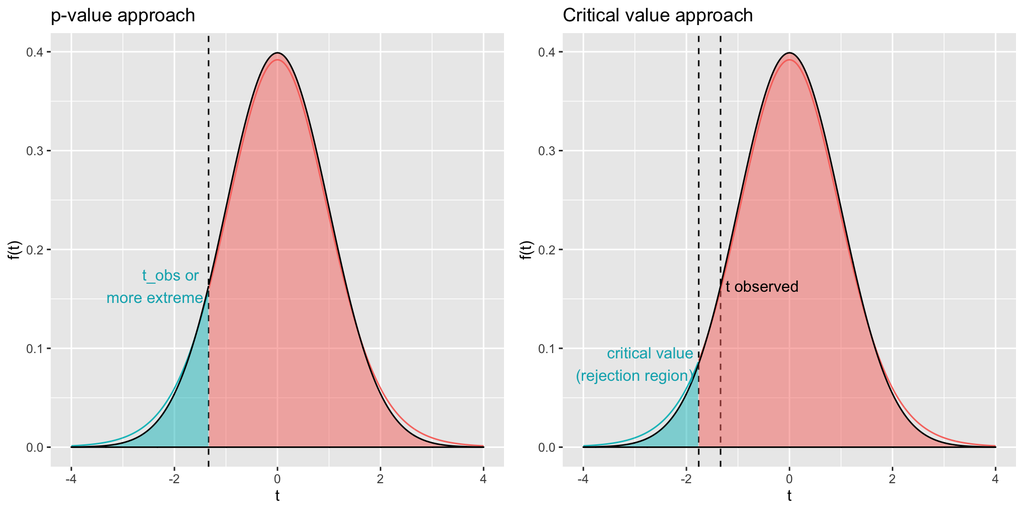

#### 4. Obtain a random sample and use it to compute the sample statistic from step 3. Call this value $\widehat{\theta}_{\text{obs}}$

For our data, the following is true:

- $n=15$,
- $\bar{x} =$ 82.4233202,
- $s_x =$ 21.9450567
- $t_{obs} =$ -1.3371738.

The above plot shows the $t(n-1)$ sampling distribution in colour, and the $Z\sim\mathcal{N}(0,1)$ in black. The $t$ has higher tails than the $Z$. This is because the t-value is the result of two random variables (sample mean and sample variance), while the z-value is only a product of only one random variable (the sample mean). However, it is easy to see that the difference between $t$ and $Z$ is reduces as $n$ increases.

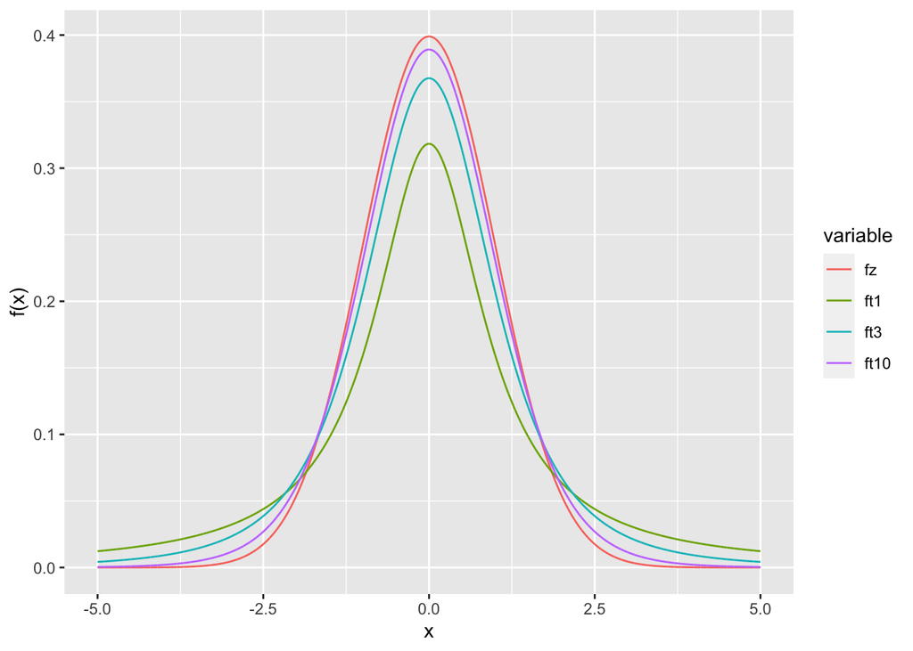

#### 5. If $\widehat{\theta}_{\text{obs}}$ is very unlikely to occur under the assumption that $H_0$ is true, then reject $H_0$. Otherwise, do not reject $H_0$.

When computing the p-value, we will turn to `pt()`. From the plot above, and from reasoning about the alternative hypothesis, we see that we need `lower.tail=TRUE`.

```r
## p-value
p_val <- pt(t_obs, n-1, lower.tail=TRUE)
p_val
```

```
## [1] 0.1012437
```

```r
## critical value
t_crit <- qt(0.05, n-1, lower.tail=TRUE)
t_crit
```

```
## [1] -1.76131
```

Finally, there is a built in function called `t.test()` that will do all of this for you.

```r
t.test(x_obs, mu=90, alternative='less')
```

```
##
##  One Sample t-test
##
## data:  x_obs
## t = -1.3372, df = 14, p-value = 0.1012
## alternative hypothesis: true mean is less than 90
## 95 percent confidence interval:
##      -Inf 92.40324
## sample estimates:
## mean of x
##  82.42332
```

## Type I versus Type II errors

### Definitions

- Hypothesis testing is about using noisy data to make decisions about what we think the true state of the universe is.
- Sometimes, our procedure for making these decisions will lead us to make the correct decision, but sometimes we will make the wrong decision.
- In the context of hypothesis testing, there are two ways to make a correct decision and two ways to make an incorrect decision. These are summarised in the following table.

|  | H0 True | H1 True |
| --- | --- | --- |
| Reject H0 | Type I error ($\alpha$) | Power ($1-\beta$) |
| Fail to reject H0 | Confidence ($1-\alpha$) | Type II error ($\beta$) |

- Here, we have introduced the concept of **power**.
- Power is the probability of correctly rejecting $H_0$.
- Power can only be computed with respect to some fully specified $H_1$.
- This is best seen with a visualisation.

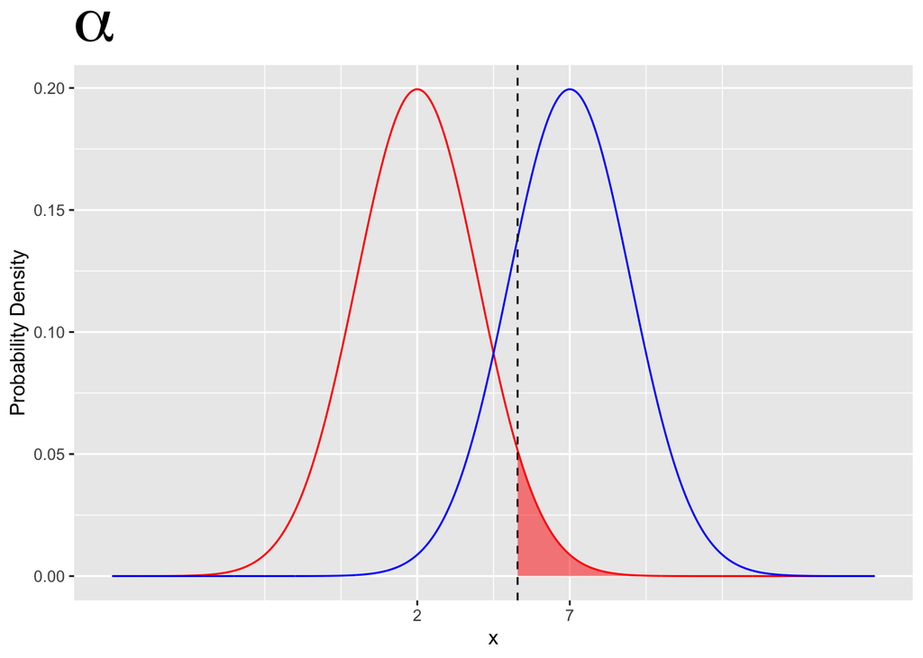

- Type I error is given by $\alpha$
- The probability of a type I error is given by the area under the $H_0$ curve in the rejection region.
- A type I error is the probability of incorrectly rejecting $H_0$
- Type I error is completely determined by $H_0$
- Type I error does not depend on $H_1$

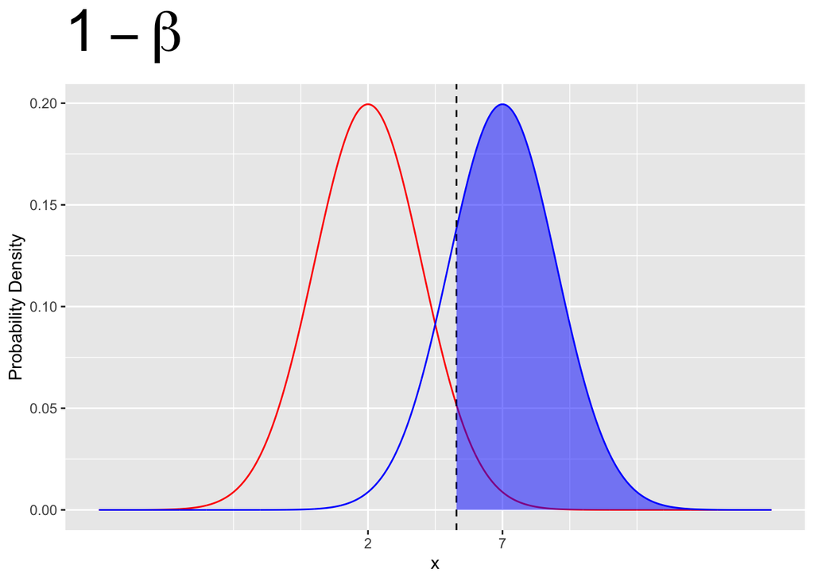

- Power is given by $1 - \beta$
- Power is given by the area under the $H_1$ curve in the rejection region.
- Power can depends on both $H_0$ and $H_1$

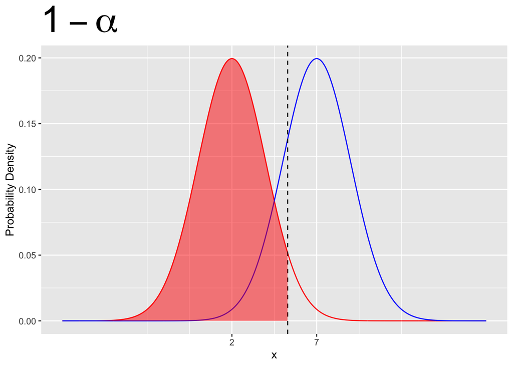

- Confidence is given by $1 - \alpha$
- Confidence is given by the area under the $H_0$ curve outside the rejection region.
- Confidence depends only on $H_0$

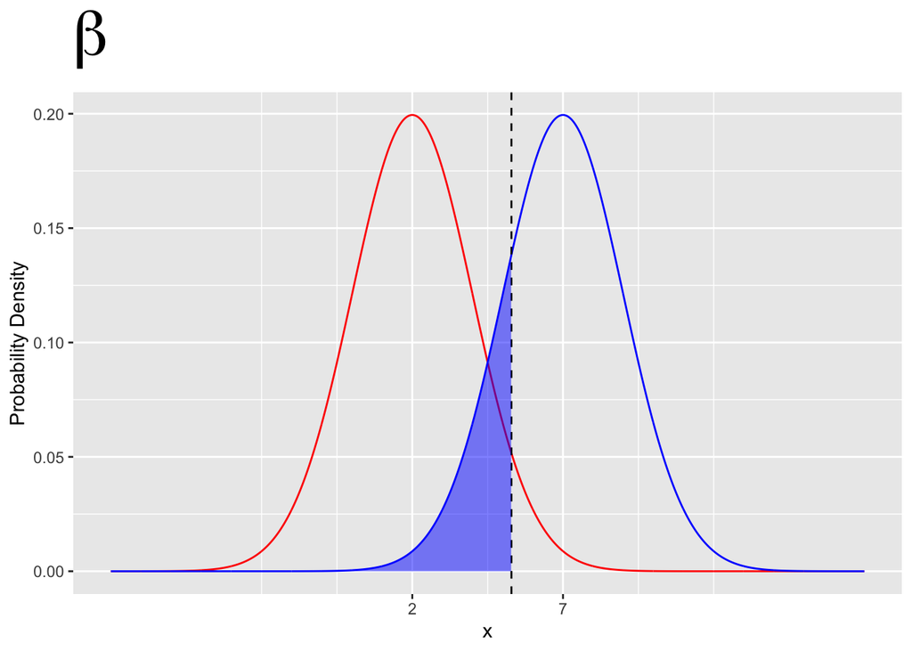

- Type II error is given by $\beta$
- The probability of a type II error is given by the area under the $H_1$ curve outside the rejection region.
- A type II error is the probability of incorrectly failing to reject $H_0$
- Type II error depends on both $H_0$ and $H1$

## power

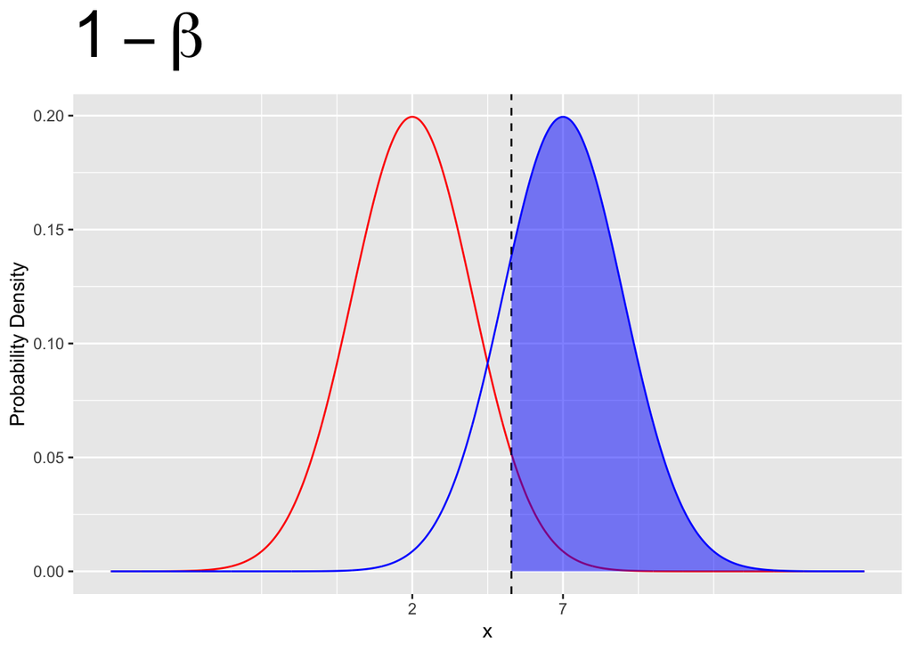

- In general, we want as much power as possible.
- This is because, if $H_0$ isn’t true, then we’d really like to reject it.
- How can we increase power?

### Increase the distance between $H_0$ and $H_1$

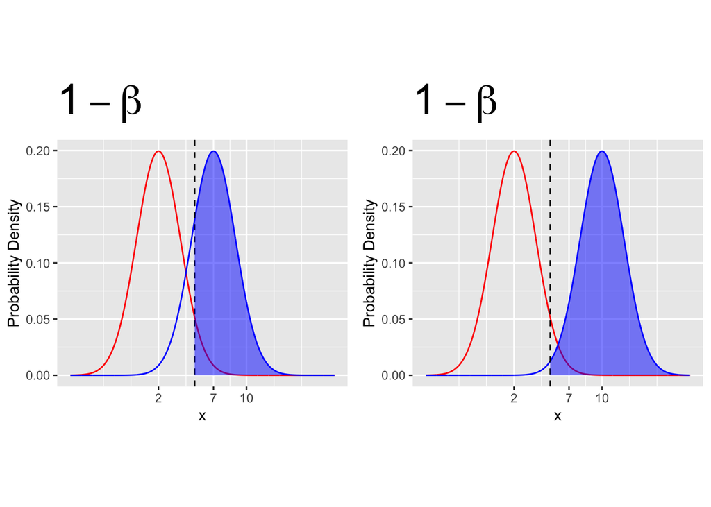

- The closer together the $H_0$ and $H_1$ distributions, the less power we have.

### Decrease the variance of $H_0$ and $H_1$

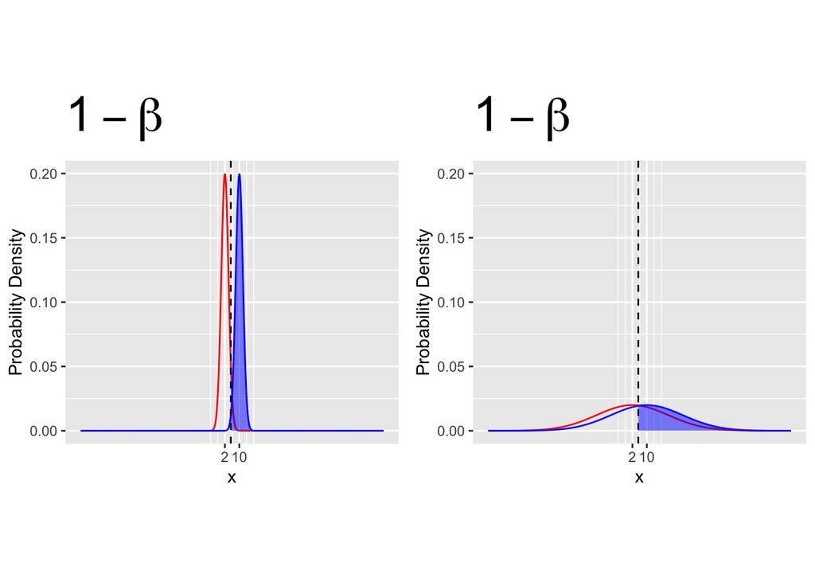

- The smaller the variance of $H_0$ and $H_1$, the greater power we have

### Power as a function of sample size

- The key point here is that, when dealing with the distribution of sample means, variance is inversely proportional to sample size.
- $\sigma_\bar{X} = \frac{\sigma_X}{\sqrt{n}}$
- This means that power increases with increased sample size.

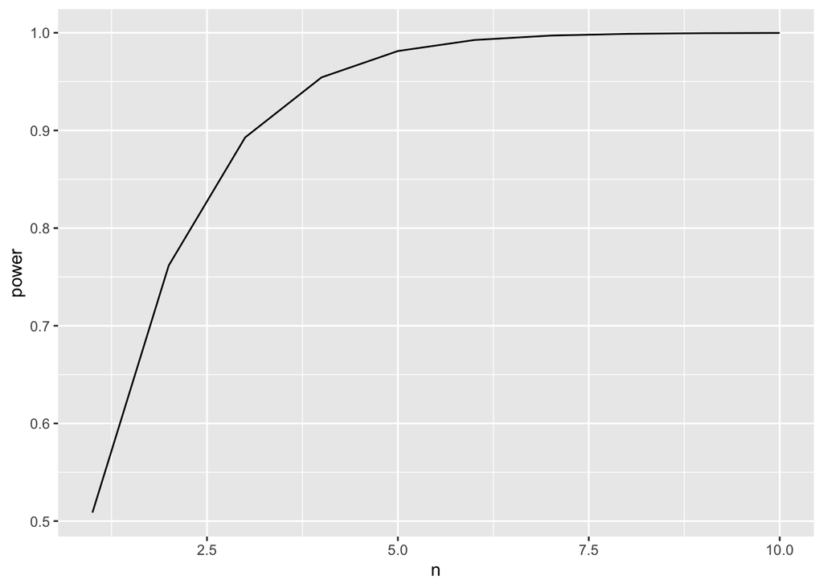

## Summary

- The **p-value** is the probability of the outcome or **a more extreme outcome** occurring under the assumption that $H_0$ is true.
- What counts as a more extreme outcome is determined by $H_1$.
- The **critical value** is the observed value for which more extreme outcomes would lead us to reject $H_0$.
- The **rejection region** is the set of all outcomes that would lead us to reject $H_0$.
- `binom.test()` can be used to efficiently perform a binomial test without manually labouring through the 5 steps.
- Must do everything long-form if dealing with a Normal sampling distribution (known variance).
- If the standard deviation of the original sampling distribution is not known, then it must be estimated, and the appropriate test to use is a t-test.
- A $t$ distribution has higher tails than a $Z$ distribution but is otherwise very similar.
- `t.test()` can be used to efficiently perform a t-test without manually labouring through the 5 steps.